# A standardized expression contrast

Synthetic teaching report: population target, estimation, and evaluation

## Question and target

All measurements and people are synthetic. The target for each feature is the group-1 minus group-0 conditional mean log2 intensity, standardized over the source population’s covariate distribution. The independent unit is a person. Everyone’s covariates contribute, including people whose whole assay is missing.

This is a standardized association. It is not automatically a causal effect, an arithmetic-mean abundance ratio, or an absolute molecules-per-cell contrast. The generator uses a fixed calibrated scale and no learned normalization.

## Procedure and assumptions

MAR conditional on group and recorded covariates, plus positive group/observation probabilities, identifies the target. 5-fold cross-fitting learns group membership and observation probabilities with logistic regressions and separate quadratic outcome regressions in each group. The augmented estimator averages held-out predictions plus joint-probability-weighted observed residual corrections. Its pointwise uncertainty uses the sample SD of estimated influence contributions divided by the square root of the number of people.

The inference argument requires independent sampling, nuisance consistency, product remainders negligible relative to n^-1/2, moment/variance conditions, and the stated probability/prediction bounds. These conditions are known or checkable in the specified teaching generator; they are not established for an actual cohort by running this code. Double-robust consistency under a misspecified nuisance is a weaker claim.

All prespecified features form the hypothesis family. BY at the configured alpha level accommodates arbitrary dependence among valid null p-values; the individual Wald tests are asymptotic. Intervals are pointwise and do not acquire simultaneous coverage from the p-value adjustment.

## Observed study and results

The sample contained 800 independent people, with 432 observed assays. There were 24 prespecified features. For gene_01, the estimate was 0.670 log2 units (SE 0.050; pointwise approximate 95% interval 0.572 to 0.767). BY at 0.05 rejected 6 null hypotheses. The known simulation truth for this feature is 0.700.

```
    n observed group0 group1 observed0 observed1     e_min     e_max    pi_min
1 800      432    353    447       221       211 0.2602384 0.8299704 0.2877082
    pi_max      q_min max_observed_weight probability_clipped mean_clipped
1 0.801157 0.08226094            11.23615                   0            0
  warning_count
1             0
```

Probability and mean clipping fractions, weight ranges, sample counts, and warnings are diagnostic records. They do not establish MAR or population overlap. The full result table includes nonsignificant features as well as discoveries.

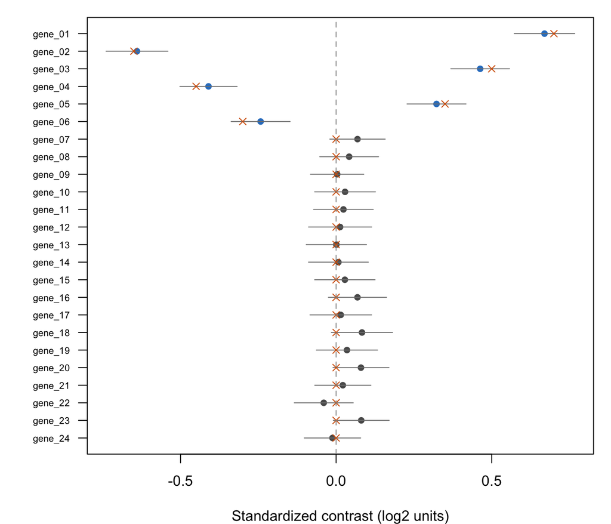

Figure 1: Estimates and pointwise Wald intervals at the configured confidence level for all prespecified synthetic features. Orange crosses show known simulation truth; blue points indicate BY rejection. The intervals are not simultaneous or selection-adjusted.

```
      gene      estimate         se        lower       upper         p_BY
1  gene_01  0.6697397005 0.04966932  0.572389627  0.76708977 1.761300e-39
2  gene_02 -0.6400349785 0.05076546 -0.739533457 -0.54053650 8.678789e-35
3  gene_03  0.4629880883 0.04820242  0.368513082  0.55746309 2.298770e-20
4  gene_04 -0.4101772488 0.04694681 -0.502191296 -0.31816320 5.420311e-17
5  gene_05  0.3226359563 0.04835757  0.227856868  0.41741504 4.577265e-10
6  gene_06 -0.2426879695 0.04836003 -0.337471894 -0.14790404 7.871356e-06
7  gene_07  0.0687310636 0.04541940 -0.020289329  0.15775146 1.000000e+00
8  gene_08  0.0418306533 0.04825977 -0.052756760  0.13641807 1.000000e+00
9  gene_09  0.0032866151 0.04366492 -0.082295057  0.08886829 1.000000e+00
10 gene_10  0.0286631291 0.04989339 -0.069126115  0.12645237 1.000000e+00
11 gene_11  0.0234872549 0.04891092 -0.072376394  0.11935090 1.000000e+00
12 gene_12  0.0127076633 0.05177327 -0.088766073  0.11418140 1.000000e+00
13 gene_13  0.0007318202 0.04940582 -0.096101815  0.09756545 1.000000e+00
14 gene_14  0.0073960085 0.04909820 -0.088834690  0.10362671 1.000000e+00
```

[output cut: 35 more lines]

## Evaluation under known truth

Each scenario uses the same simulated datasets and fold allocations. The fully correct models support the stated efficient-inference argument. The two singly correct scenarios investigate consistency; their interval validity requires a separate argument. Both-wrong fits deliberately challenge calibration.

```
     n             scenario attempted successful sentinel_bias   bias_mcse
1  400         Both correct       100        100  -0.005799467 0.006943310
2  400 Outcome only correct       100        100  -0.004718295 0.006827738
3  400 Weights only correct       100        100  -0.032840763 0.010586325
4  400           Both wrong       100        100   0.371145986 0.009351854
5 1200         Both correct       100        100  -0.003759116 0.003970181
6 1200 Outcome only correct       100        100  -0.003351759 0.003935657
7 1200 Weights only correct       100        100  -0.018433270 0.006295249
8 1200           Both wrong       100        100   0.372832048 0.006000246
```

```
     n     scenario   coverage coverage_mcse         fdr    fdr_mcse
1  400 Both correct 0.95833333   0.005772288 0.005595238 0.003296084
4  400   Both wrong 0.12833333   0.015036898 0.737973926 0.017038970
5 1200 Both correct 0.95125000   0.008185880 0.010714286 0.004439868
8 1200   Both wrong 0.01666667   0.003792085 0.803885440 0.002060112
  true_positive_fraction
1              0.9783333
4              0.6800000
5              1.0000000
8              0.7216667
```

Bias refers to the prespecified null sentinel gene. Coverage is averaged over the fixed feature family within each dataset, then over datasets. FDR is the average replicate FDP, using zero FDP for an analysis with no discoveries. MCSE uses variation across independent datasets, not independent genes. Performance summaries are conditional on successful complete-family fits; success counts are therefore part of the results. All failed attempts remain in the replicate record.

The configured experiment uses 100 replicates per sample size/scenario, with reported Monte Carlo uncertainty. A zero estimated FDR or zero plug-in MCSE does not prove zero population FDR. This experiment does not establish validity in high-dimensional, dependent-person, MNAR, or unsupported populations.

## Reproducibility and limits

This report reads the explicit directory results. The archive includes observed synthetic inputs, truth separately for evaluation, functions, configuration, per-person contributions, nuisance predictions, diagnostics, all simulation attempts, manifests, warnings, session information, and report source. Run the documented commands from a fresh session into a new directory to reproduce it. File checks establish identity/change, not scientific correctness.

The synthetic measurement model is not a substitute for assay-specific calibration, design and selection arguments in real gene-expression data. Greater precision or more discoveries do not establish a causal interpretation.